# TIG’R - Graphique R-base

### Ajout d’éléménts

Une fois le graphique construit, plusieurs fonctions primitives vous permettre d’ajouter différents éléments. Exemple :

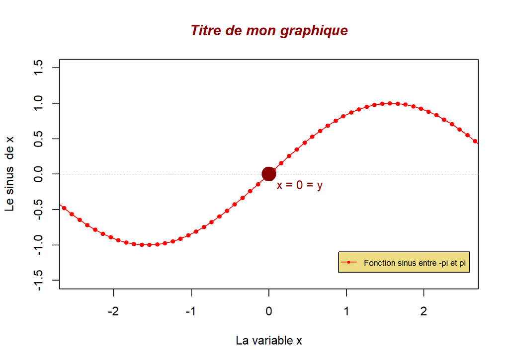

```r
plot(y ~ x,
  type = "o", # type de tracé: points ("p"), lignes ("l"), les deux ("b" ou "o"), ...
  col = "red", # couleur, tapez `colours()` pour la liste complète
  pch = 20, # type de symboles, un chiffre entre 0 et 25, tapez `?points`
  cex = 1.1, # taille des symboles
  lty = 1, # type de lignes, un chiffre entre 1 et 6
  lwd = 1.4, # taille de lignes
  xlim = c(-2.5, 2.5), # limites de l'axe des x
  ylim = c(-1.5, 1.5), # limites de l'axe des y)
  xlab = "La variable x", # titre pour l'axe des x
  ylab = "Le sinus  de x") # titre pour l'axe des y)


# Ajout d'une LEGENDE
legend(x = 0.9, # Emplacement de la légende (coin haut gauche)
       y = -1.1, # Emplacement de la légende (coin haut gauche)
       legend = "Fonction sinus entre -pi et pi",
       bg = "lightgoldenrod",
       col = "red",
       pch = 20,
       cex = 0.7, # Taille de lé lagende
       lty = 1,
       lwd = 1.4)

# Ajout d'une LIGNE (horizontale)
abline(h = 0, # Coupe l'axe des y à cette valeur
       lty = 2, # Type de ligne
       lwd = 0.5, # épaisseur
       col = "grey50")

# Ajout d'un POINT
points(x = -0,
       y = 0,
       col = "red4",
       pch = 20,# Type de symbol
       cex = 4)

# Ajout de TEXTE
text("x = 0 = y", # Texte à afficher
     x = 0.4, # Emplacement du texte (centre)
     y = -0.16, # Emplacement du texte (centre)
     col = "red4")

# Ajout d'un TITRE
title("Titre de mon graphique",
      cex.main = 1.2,
      font.main= 4,
      col.main= "red4")
```

### Fenêtre graphique

Deux fonctions - `par()` et `layout()` - permettent de gérer les paramètres graphiques, comme la disposition des figures, les marges, les axes, la police… :

Exemple d’utilisation de la fonction `par()` qui contient un grand nombre d’arguments possibles (cf. `?par`) :

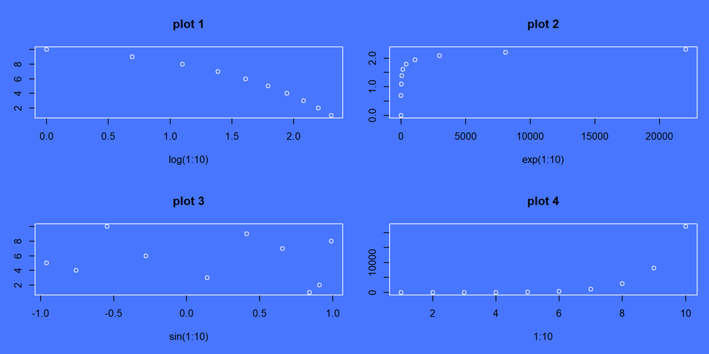

```r
par(bg = "royalblue1", # Couleur de fond
    col= "white",      # couleur du graphique
    mfrow = c(2,2),    # Fenêtre découper en deux lignes / deux colonnes (4 graphiques)
    mar = c(5,3,4,1))  # Gestion des marges pour chaque graphique (B,L,T,R)


plot(x = log(1:10), y = 10:1, main = "plot 1")

plot(x = exp(1:10), y = log(1:10), main = "plot 2")

plot(x = sin(1:10), y = 1:10, main = "plot 3")

plot(x = 1:10, y = exp(1:10), main = "plot 4")
```

`layout()` propose moins d’arguments mais permet un meilleur ajustement de la disposition des figures. Pour cela, il est nécessaire de construire une matrice pour indiquer la position et l’espace de chaque graphique ajouté. Exemple :

```r
matrix(c(1,1,1,2,0,3,2,0,3),  3,  3,  byrow = TRUE)
```

```
     [,1] [,2] [,3]
[1,]    1    1    1
[2,]    2    0    3
[3,]    2    0    3
```

Avec la matrice ci-dessus, la fenêtre graphique sera paramétrée pour contenir trois graphiques. Le graphique 1 occupera toute la première ligne. le graphique 2 occupera les deux dernières lignes de la première colonne, et le 3e sera situé dans les deux dernières lignes de la dernière colonne. Exemple :

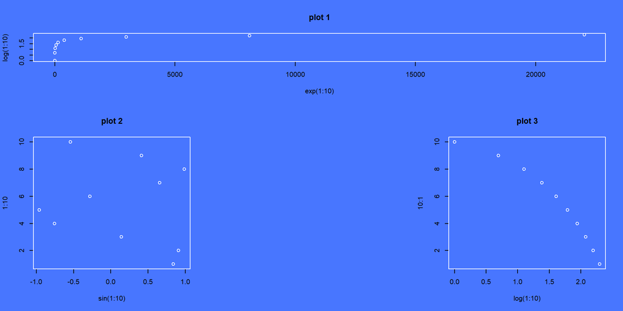

```r
par(bg  = "royalblue1",  col= "white")

# Découpage de la fenêtre graphique
layout(mat = matrix(c(1,1,1,2,0,3,2,0,3),  3,  3,  byrow = TRUE))

plot(x = exp(1:10), y = log(1:10), main = "plot 1")
plot(x = sin(1:10), y = 1:10, main = "plot 2")
plot(x = log(1:10), y = 10:1, main = "plot 3")
```

## Principaux graphiques

### Variable Quanti.

Pour représenter la distribution d’un variable quantitative, plusieurs types de graphiques peuvent être utilisés.

#### stripchart()

La fonction `stripchart()` permet de représenter la distribution d’une variable quantitative.

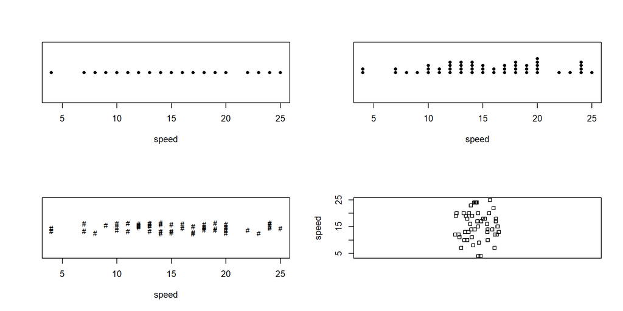

```r
par(mfrow = c(2,2))

# gauche supérieur
stripchart(cars$speed, xlab = "speed", pch = 16)

# droite supérieur
stripchart(cars$speed, xlab = "speed", method = "stack", pch = 16)

# gauche inférieur
stripchart(cars$speed, xlab = "speed", method = "jitter", pch = "#")

# droite inférieur
stripchart(cars$speed, ylab = "speed", method = "jitter", vertical = TRUE)
```

#### hist()

La fonction `hist()` permet de construire un histogramme.

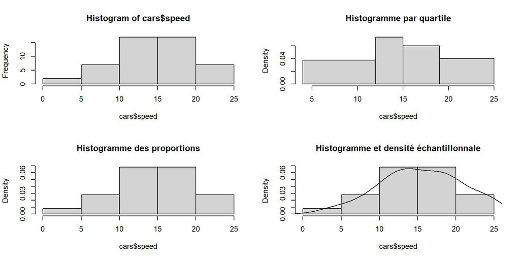

```r
par(mfrow = c(2,2))

# gauche supérieur
hist(cars$speed)

# droite supérieur
hist(cars$speed, breaks = quantile(cars$speed), main = "Histogramme par quartile")

# gauche inférieur
hist(cars$speed, freq = FALSE, main = "Histogramme des proportions")

# droite inférieur
hist(cars$speed, freq = FALSE, main = "Histogramme et densité échantillonnale")
lines(density(cars$speed))
```

#### boxplot()

La fonction `boxplot()`permet de construire une boîte à moustache. Elle peut être associée à la fonction `stripchart()`.

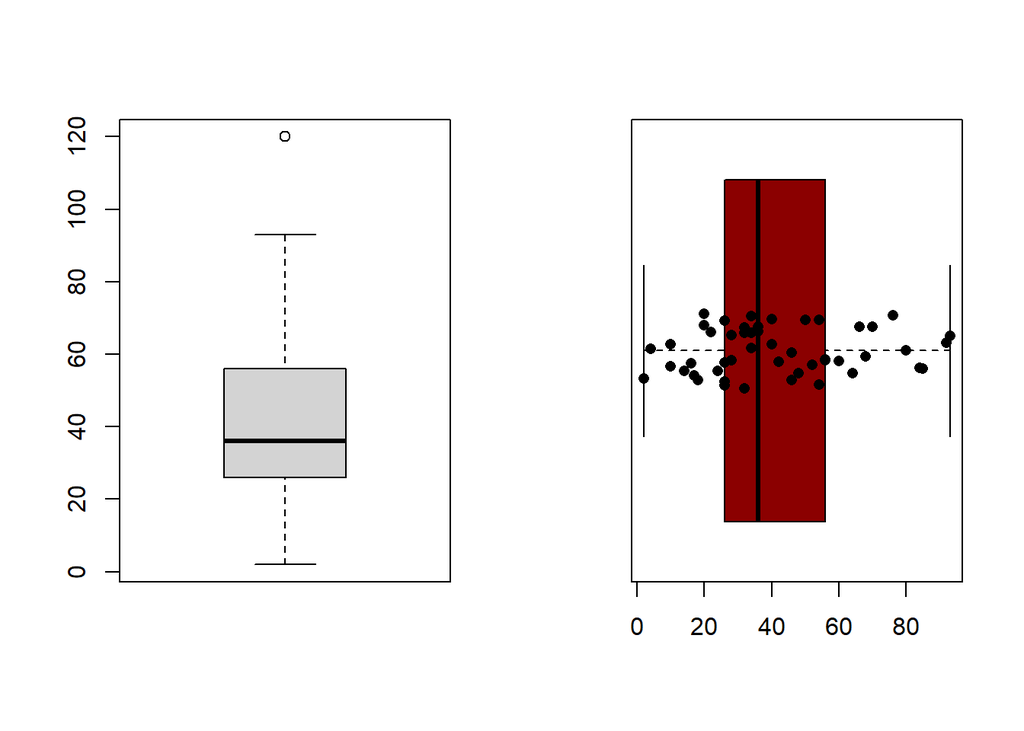

```r
par(mfrow = c(1,2))

# gauche
boxplot(cars$dist)

# droite
boxplot(cars$dist, horizontal=T, varwidth= TRUE, col = "red4", outline = FALSE)
stripchart(cars$dist,  pch = 16, metho = "jitter", add = TRUE)
```

### 2 variables Quanti.

#### plot()

Utilisez la fonction `plot()` pour représenter deux variables quantitatives.

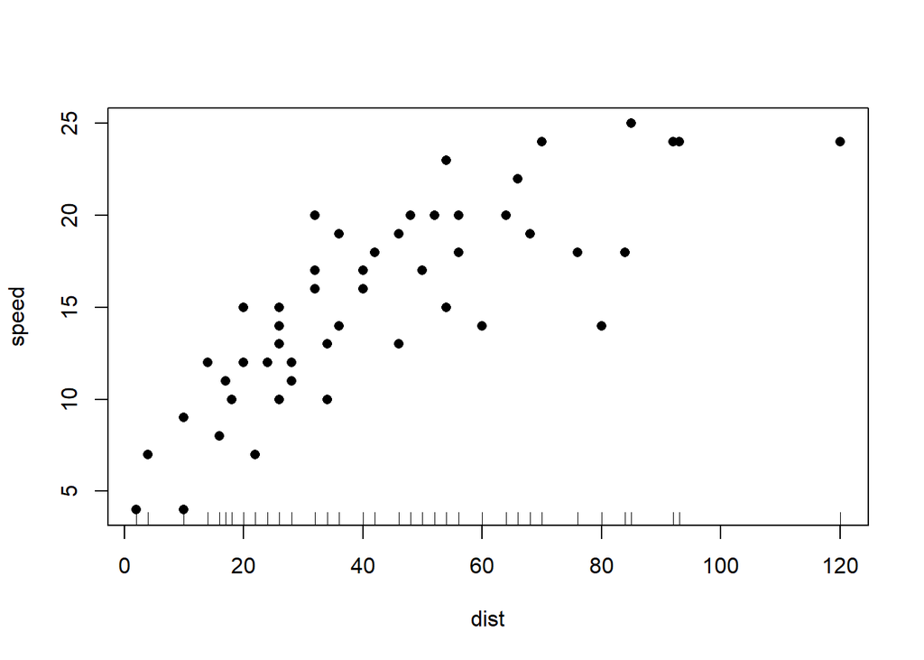

```r
plot(speed ~ dist, data = cars, pch = 16)

# Ajout d'une marque pour chaque individus le long de l'axe des abcisses
rug(cars$dist)
```

### Variable Quali.

#### plot()

La fonction `plot()` peut être utilisée pour une variable qualitative. Pour cela la variable doit être stockée dans le format `factor`.

```r
class(esoph$alcgp)
```

```
[1] "ordered" "factor"
```

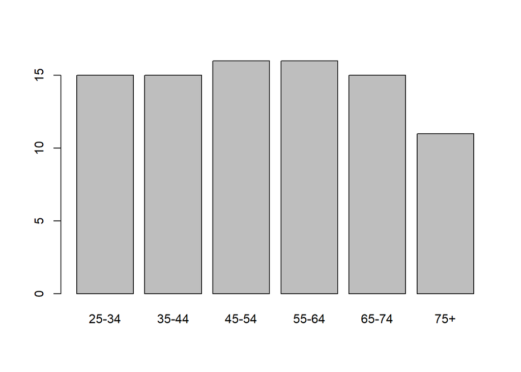

```r
plot(esoph$agegp)
```

#### barplot()

Vous pouvez utiliser la fonction `barplot()` sur une table de fréquence.

```r
# Calcul table de fréquence
table_freq <- table(esoph$agegp)

# Fréquence par modalité
table_freq
```

```
25-34 35-44 45-54 55-64 65-74   75+
   15    15    16    16    15    11
```

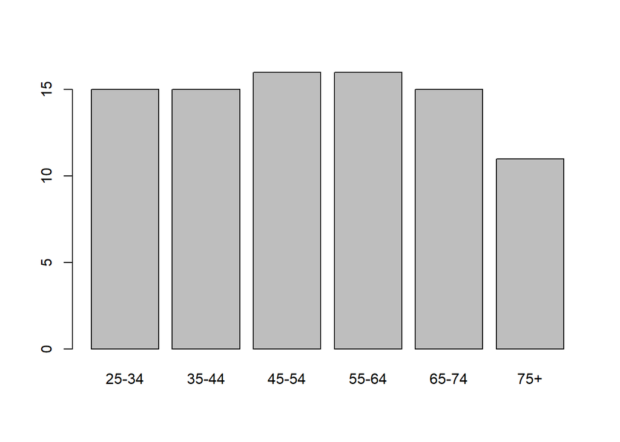

```r
barplot(table_freq )
```

### 2 variables Quali.

Comme avec une variable qualitative, vous pouvez utiliser les fonction `plot()` et `barplot()` pour représenter La répartition d’individus en fonction de deux variables qualitatives.

#### plot()

Comme avec une seule variable, **les variables qualitatives croisées doivent être stockée en `factor`**.

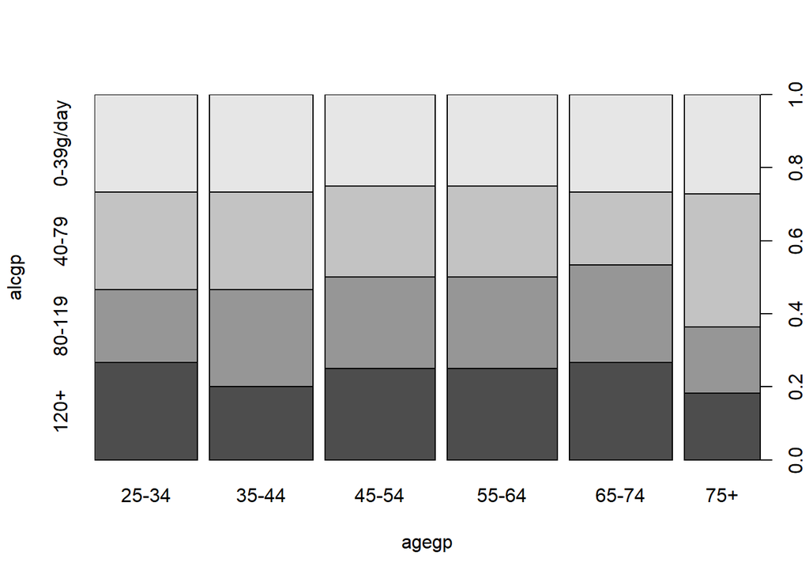

```r
plot(alcgp ~ agegp, data = esoph)
```

#### barplot()

La fonction `barplot` fonctionne également sur deux variables qualitatives. Dans un premier temps, calculez le tableau croisé à partir des deux variables qualitatives ciblées :

```r
# Calcul table de fréquence
table_freq <- table(esoph$alcgp, esoph$agegp)

# Fréquence par modalité
table_freq
```

```
            25-34 35-44 45-54 55-64 65-74 75+
  0-39g/day     4     4     4     4     4   3
  40-79         4     4     4     4     3   4
  80-119        3     4     4     4     4   2
  120+          4     3     4     4     4   2
```

Puis utilisez la fonction `barplot()` :

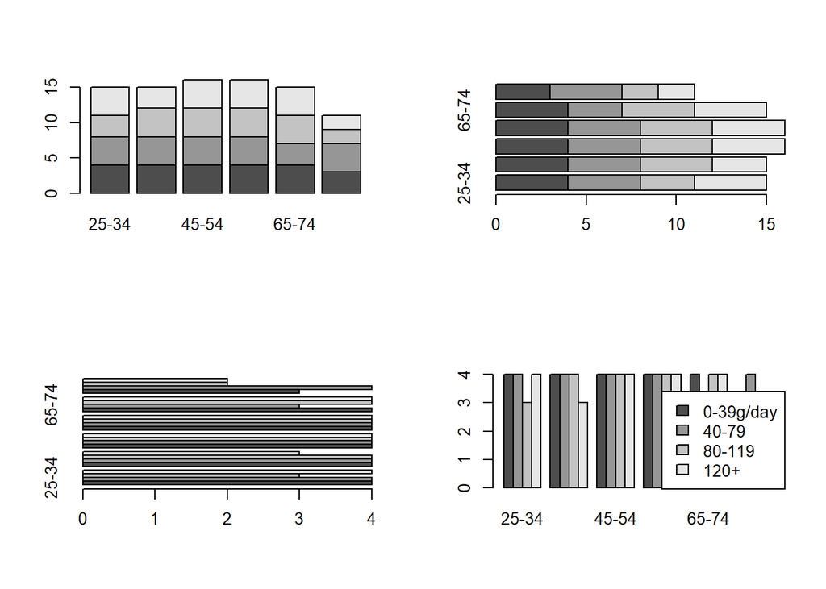

```r
par(mfrow = c(2,2))

# gauche supérieur
barplot(table_freq)

# droite supérieur
barplot(table_freq, horiz = TRUE)

# gauche inférieur
barplot(table_freq, horiz = TRUE, beside=TRUE)

# droite inférieur
barplot(table_freq, beside=TRUE, legend.text = levels(esoph$alcgp),
        args.legend=list(x="bottomright"))
```

### Quanti. et Quali.

#### plot()

La fonction généraliste `plot()` peut être utilisée. Si la variable qualitative est appelée en première, le graphique prendra la forme d’un *spine plot* (%). Dans le cas contraire, la fonction renverra un ensemble de *boxplots*.

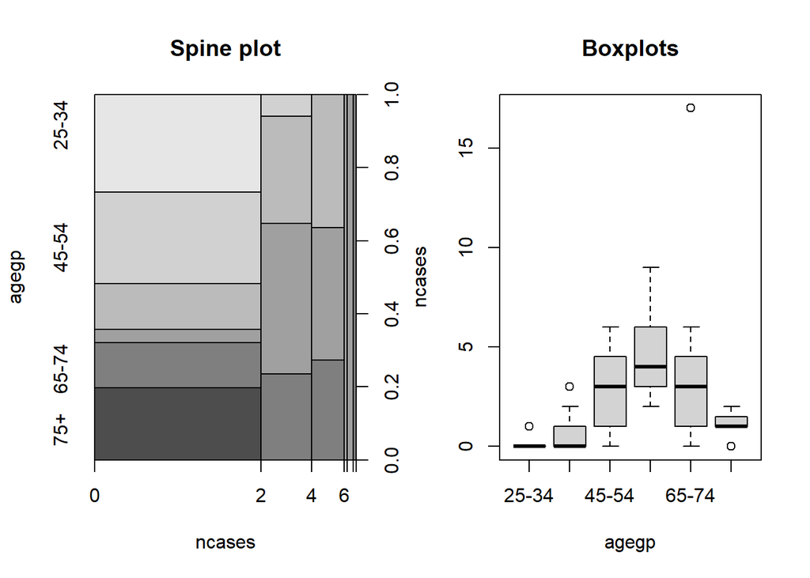

```r
par(mfrow = c(1,2))


# Spine plot
plot(agegp ~ ncases, data = esoph, main = "Spine plot")

# Boxplot
plot(ncases ~ agegp, data = esoph, main = "Boxplots")
```

Il est également possible d’utiliser directement la fonction boxplot pour représenter la distribution de chaque individus pour une variable quantitative, par modalité d’une variable qualitative :

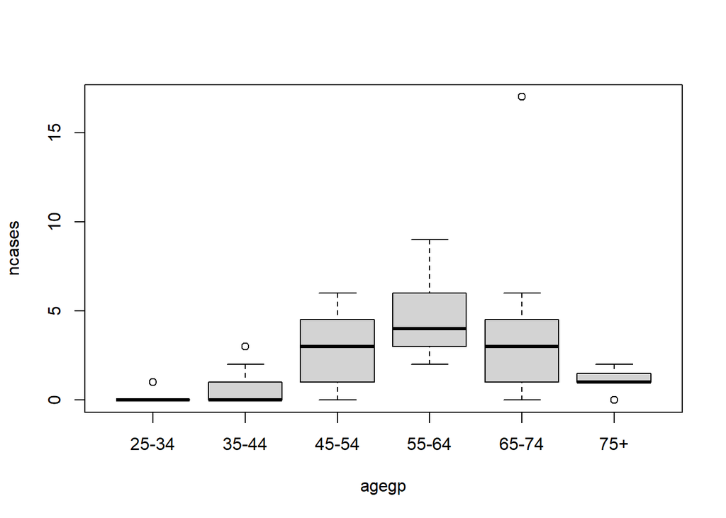

```r
boxplot(ncases ~ agegp, data = esoph)
```

L’argument `col` de la fonction `plot()` permet aussi de représenter trois variables (quantitative ~ quantitative + qualitative). Pour cela, il est préférable d’utiliser une variable qualitative stockée en format `factor`.

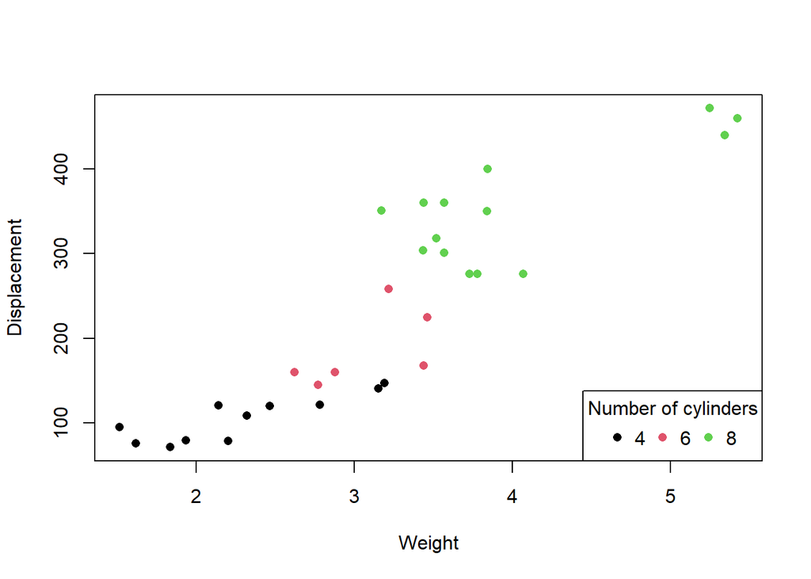

```r
# Conversion de la variable qualitative en format factor
mtcars$cyl <- as.factor(mtcars$cyl)

# Nuage de point
plot(disp ~ wt,
     data = mtcars,
     col = cyl, # Couleur des points en fonction d'une variable qualitative
     pch = 16,
     xlab = "Weight",
     ylab = "Displacement")

# Ajout d'une légende
legend(x = "bottomright",
       title = "Number of cylinders",
       legend = levels(mtcars$cyl),
       col =  1:3,
       ncol = 3,
       pch = 16)
```